# COVID-19 Visualization

Fiona McLean

4/28/2020

## Introduction

A pandemic presents harsh new challenges to our every day lives. Many people are worried about the health and safety of their loved ones, workplaces and schools are closed, and life as we have known it has changed drastically. It is easy to feel like there is a loss of control, like were driving down a road and suddenly we can’t see out of our windshield. Luckily during these times impartial data can help us. Even if we struggle to control the virus itself, data provides a unique and unbiased view into what is happening and where we may be heading. Data analysis strips away opinions and sensationalism to provide us with the closest thing we have to truth, defogging our windshield and allowing us to steer safely.

I’ve decided to create some visualizations using [COVID-19 data from the New York Times](https://github.com/nytimes/covid-19-data), which contains cases and deaths from COVID-19 for every state and county in the United States. For this report I used data up to April 25th. Although no concrete conclusions can be drawn from visualizations, rigid statistical testing is necessary for such claims, the visualizations do give us an idea of what is going on in our world. They’re also an easy and unbiased way to digest information. If you’re like me, you’ll also find them to be beautiful. I mostly focused on New York State, as it’s the state which will soon be my residence, for this analysis. I have not modeled or predicted future COVID-19 cases or deaths. Models for subjects as important as COVID-19 should be built by professionals and should be used with care. It’s important to remember that all models are wrong, but some are useful.

I hope you enjoy my visualizations.

### New York State

As I mentioned earlier, I am most interested in COVID-19 infections in New York State. New York State has been the hardest hit state in the United States, with by far the most COVID-19 cases and deaths.

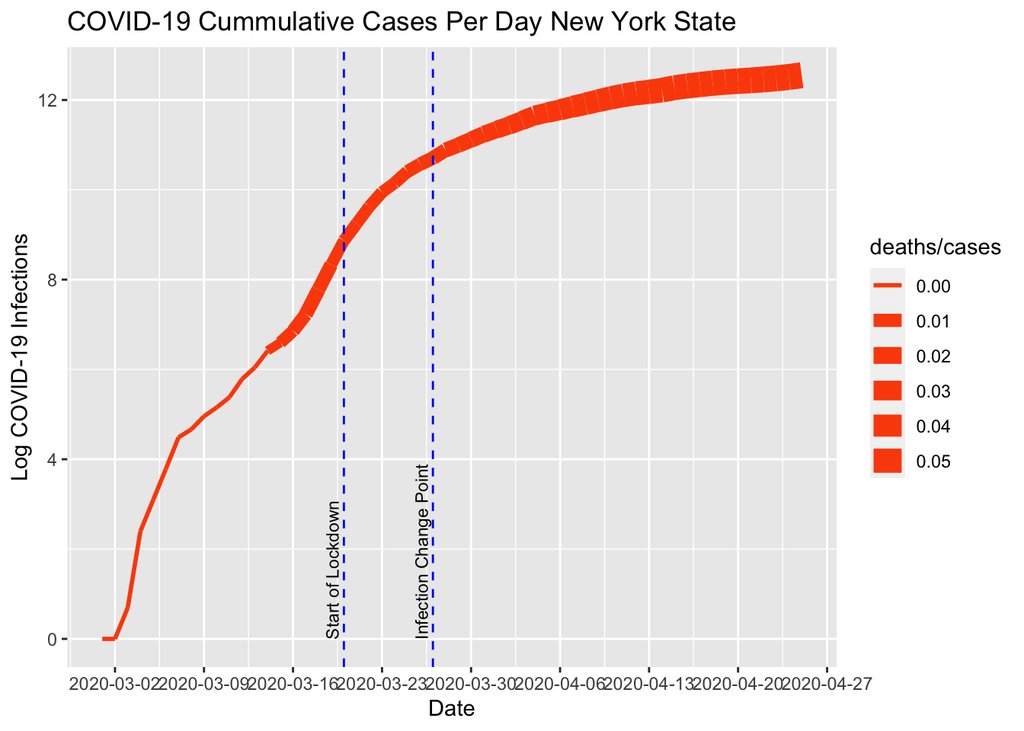

The graph above shows the log cumulative COVID-19 infections per day in New York State. A log scale is used since we are primarily interested in the rate of change of COVID-19 infections over time. We see that the infection rate seems to be stabilizing. March 20th was the official start of lock down in New York State. Several days later we observe a change point, or a statistically significant change in the time series trend. While we cannot state that the lock down was the cause of the change in the trend of COVID-19 infections, it appears to have an effect. We also observe that the death to cases ratio increases over time, which is expected as COVID-19 infections often do not prove fatal for several days to weeks after first contracting the disease.

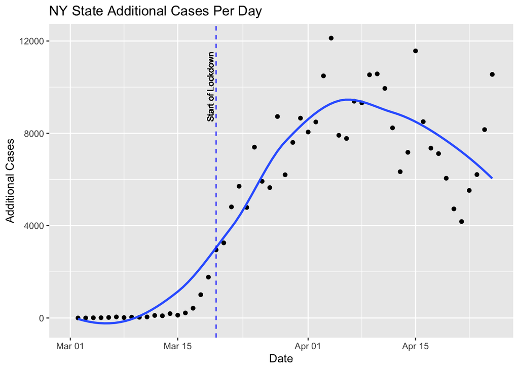

Here we see the the number of new cases recorded each day in New York State, as well as a smoothing function to show the trend. It appears that the number of new cases diagnosed each day is decreasing, which is a great sign.

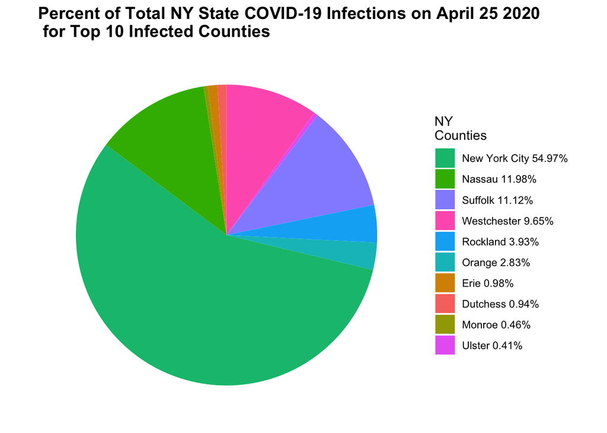

To better understand how COVID-19 infections differ within New York State, I have broken down the total infections and shown the percentage occurring in the top ten infected counties of New York. It is clear that New York City had the most COVID-19 infections by volume when compared to other counties. Importantly, this graph does not consider the population of each county, which is necessary to understand how pervasive the virus is in the county.

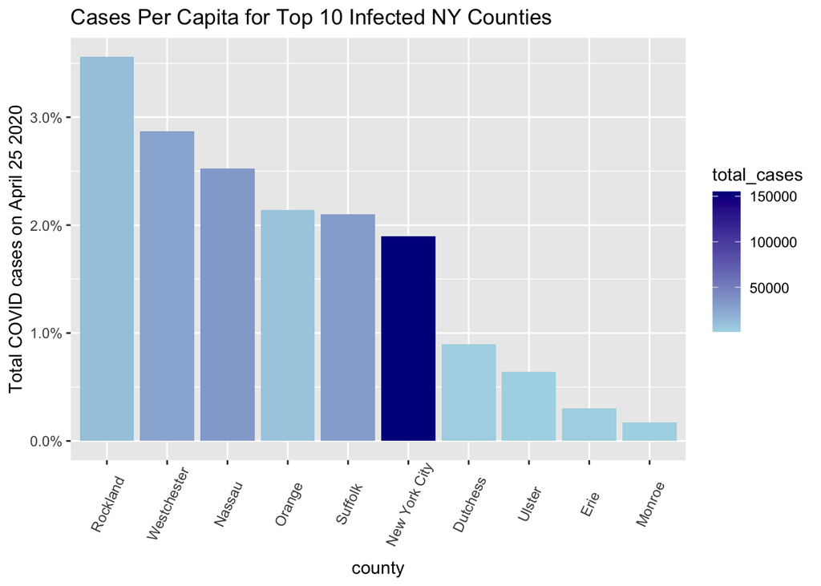

Here we see that Rockland County is the most infected county in New York State. The data suggests that more than 3% of Rockland county has been infected by the virus. We see that given the large population, New York City is actually faring well compared to other counties in New York.

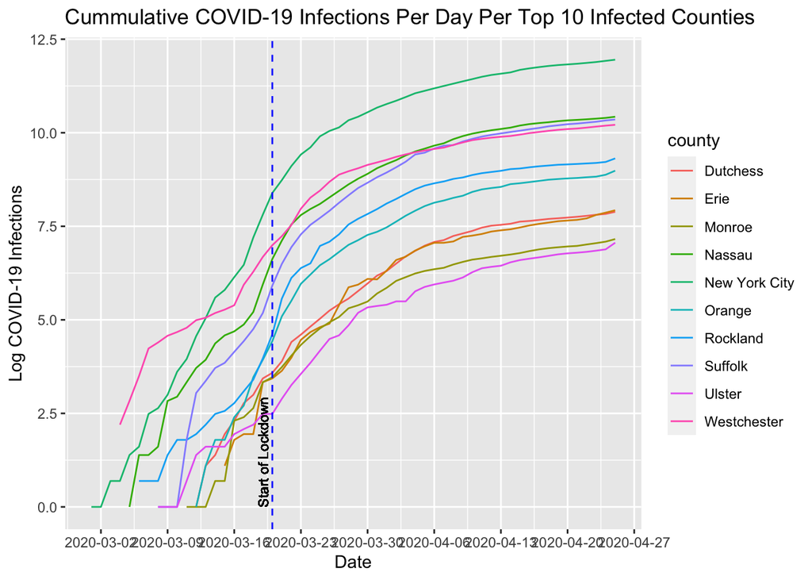

Finally, I plot the log cumulative COVID-19 infections per day for each of the top 10 infected counties in New York State. We see that, for the most part, the counties infection trend is similar.

### United States

Once I had a better understanding of how COVID-19 was infection New York State, I was interested to compare New York’s infection trend to other states.

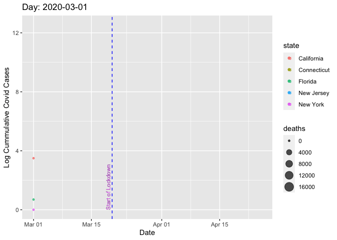

Log of cummulative cases per day per states

This visualization helps to show how the rate of infection is changing in New York compared to other states. By seeing the trend over time, we can observe that the rate of infection begins to slow down for all states after an initial speedy rise.

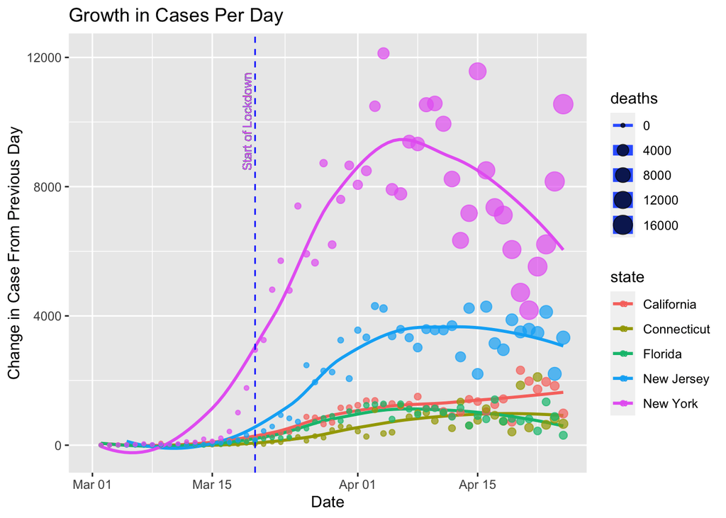

Here we consider the increase in cases from the previous day for the previously analyzed states. We observe most of the states are experiencing decreases in the rate of COVID infections from peak infection state. New York is experiencing a sharp decline in new cases, while California is seeing a slight uptick recently.

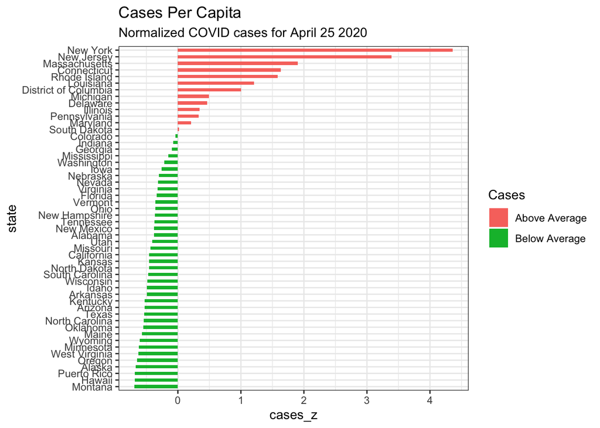

This chart allows us to compare the variation in COVID-19 cases compared to the mean cases per capita. We can see that New York State has a Z score above 4, meaning that it is 4 standard deviations away from the mean COVID-19 cases. This clearly shows how extreme the cases per capita are in New York compared to other states. The North East seems to be heavily hit by COVID-19 compared to the rest of the country.

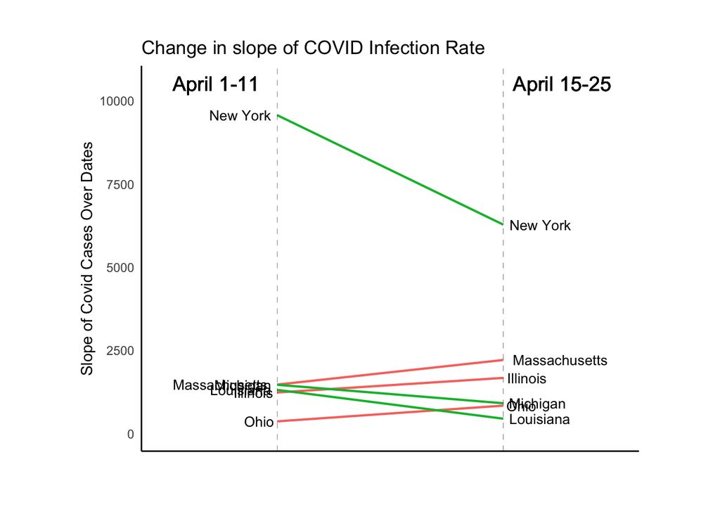

Here we consider the three states with the greatest decrease in the slope of COVID-19 infections and the three states with the greatest increase in the slope of COVID-19 infections. The slope during each time period was calculated by regressing the infections over a ten day period to find the slope of the cumulative increase in COVID cases. The graph shows that New York State, Michigan, and Louisiana have shown the greatest improvements while Massachusetts, Illinois, and Ohio have seen an increase in the slope of COVID-19 infections.

## Conclusion

I hope you have found my COVID-19 visualizations interesting and informative. Please feel free to write to me with suggestions or comments. I hope you are staying safe and healthy.